# Wrangling and Analyze Data

### fixing rating_denominator

```python
df1.rating_denominator.describe()
```

```
count    2278.000000
mean       10.413521
std         6.376645
min         2.000000
25%        10.000000
50%        10.000000
75%        10.000000
max       170.000000
Name: rating_denominator, dtype: float64
```

```python
df1.query('rating_denominator!=10').rating_denominator.value_counts()
```

```
50     3
11     3
80     2
90     1
120    1
150    1
20     1
110    1
170    1
40     1
7      1
70     1
2      1
Name: rating_denominator, dtype: int64
```

```python
# most of the denominator has rating larger than 10 that turns out the be group photo
df1.query('rating_denominator==2') # this was a error in extracting data
```

|  | tweet_id | timestamp | source | text | expanded_urls | rating_numerator | rating_denominator | name | doggo | floofer | pupper | puppo |
| --- | --- | --- | --- | --- | --- | --- | --- | --- | --- | --- | --- | --- |
| 2335 | 666287406224695296 | 2015-11-16 16:11:11 +0000 | <a href="http://twitter.com/download/iphone" r... | This is an Albanian 3 1/2 legged Episcopalian... | https://twitter.com/dog_rates/status/666287406... | 1 | 2 | an | None | None | None | None |

[figure not shown]

[figure not shown]

```python
# this dog deserved an update on rating
df1.loc[2335, 'rating_denominator'] = 10
df1.loc[2335, 'rating_numerator'] = 9
```

```python
# this one is no-rating, and 24/7 was extracted not for a rating
df1.query('rating_denominator==7').text
```

```
516    Meet Sam. She smiles 24/7 &amp; secretly aspir...
Name: text, dtype: object
```

```python
# filter out all tweet from group photo
df1= df1.query('rating_denominator==10')
df1.shape
```

```
(2261, 12)
```

```python
### let working on numerator
df1.query('rating_numerator >= 15').sample(3)
```

|  | tweet_id | timestamp | source | text | expanded_urls | rating_numerator | rating_denominator | name | doggo | floofer | pupper | puppo |
| --- | --- | --- | --- | --- | --- | --- | --- | --- | --- | --- | --- | --- |
| 763 | 778027034220126208 | 2016-09-20 00:24:34 +0000 | <a href="http://twitter.com/download/iphone" r... | This is Sophie. She's a Jubilant Bush Pupper. ... | https://twitter.com/dog_rates/status/778027034... | 27 | 10 | Sophie | None | None | pupper | None |
| 285 | 838916489579200512 | 2017-03-07 00:57:32 +0000 | <a href="http://twitter.com/download/iphone" r... | RT @KibaDva: I collected all the good dogs!! 1... | https://twitter.com/KibaDva/status/83890598062... | 15 | 10 | None | None | None | None | None |
| 2074 | 670842764863651840 | 2015-11-29 05:52:33 +0000 | <a href="http://twitter.com/download/iphone" r... | After so many requests... here you go.\n\nGood... | https://twitter.com/dog_rates/status/670842764... | 420 | 10 | None | None | None | None | None |

- decimal rating makes the extraction inaccurate
- [they'are good dogs, Brent](https://knowyourmeme.com/memes/theyre-good-dogs-brent) provides some insight about the rating
- some rating can be fixed (decimal rating), other is just for a special reason
- [Snoop Dogg (the rapper)](https://en.wikipedia.org/wiki/Snoop_Dogg) has a rating of 420/10

[figure not shown]

```python
# only select rating with a reasonable value
df1 = df1.query('rating_numerator <=15')
```

### convert timestamp to datetime object

```python
# remove trailing +0000
df1.timestamp = df1.timestamp.str.strip('+0000')
```

```python
df1.timestamp = pd.to_datetime(df1.timestamp, format='%Y-%m-%d %H:%M:%S')
```

### extract the source of photo by removing extra html tag

```python
df1.source.unique()
```

```
array(['<a href="http://twitter.com/download/iphone" rel="nofollow">Twitter for iPhone</a>',
       '<a href="http://twitter.com" rel="nofollow">Twitter Web Client</a>',
       '<a href="http://vine.co" rel="nofollow">Vine - Make a Scene</a>',
       '<a href="https://about.twitter.com/products/tweetdeck" rel="nofollow">TweetDeck</a>'],
      dtype=object)
```

```python
def get_source(input_):
    return input_.split('">')[1].split('<')[0]
```

```python
df1.source = df1.source.apply(get_source)
```

### Change name with `a, an, the` to `None`

```python
df1.name.value_counts().nlargest(10)
```

```
None       654
a           54
Charlie     12
Lucy        11
Oliver      11
Cooper      11
Tucker      10
Penny       10
Lola        10
Bo           9
Name: name, dtype: int64
```

```python
df1.loc[df1.name=='a', 'name'] = None
df1.loc[df1.name=='an', 'name'] = None
df1.loc[df1.name=='the', 'name'] == None
df1.name.value_counts()
```

```
None        654
Charlie      12
Lucy         11
Oliver       11
Cooper       11
           ...
Clyde         1
Tycho         1
Kenzie        1
Aqua          1
Sundance      1
Name: name, Length: 950, dtype: int64
```

```python
# remove numerator and demoninator columns
df1.drop(columns = ['rating_denominator'], inplace=True)
df1.rename(columns = {'rating_numerator': 'rating'}, inplace=True)
```

### melting columns `doggo, floofer, pupper, puppo` to one columns

```python
df1 = pd.melt(df1, id_vars=['tweet_id', 'timestamp', 'source', 'text', 'expanded_urls', 'rating', 'name'],\
               value_vars=['doggo','floofer', 'pupper', 'puppo'],\
               var_name='var_name', value_name='stage')
```

```python
df1.stage.value_counts()
```

```
None       8636
pupper      252
doggo        93
puppo        29
floofer      10
Name: stage, dtype: int64
```

```python
# remove extra row after melting
df1 = df1.sort_values('stage').drop_duplicates('tweet_id', keep='last')
```

```python
df1.stage.value_counts()
```

```
None       1884
pupper      252
doggo        80
puppo        29
floofer      10
Name: stage, dtype: int64
```

### clean `df2 (image_predictions)` by selecting confidence, breed when the prediction == True

- the function below was from [this project](https://github.com/paulstancliffe/Udacity-WeRateDogs-Project/blob/master/wrangle_act.ipynb)

```python
breeds = list()
conf = list()
def get_prediction(row):
    if row['p1_dog'] == True:
        breeds.append(row['p1'])
        conf.append(row['p1_conf'])
    elif row['p2_dog'] == True:
        breeds.append(row['p2'])
        conf.append(row['p2_conf'])
    elif row['p3_dog'] == True:
        breeds.append(row['p3'])
        conf.append(row['p3_conf'])
    else:
        breeds.append('unknown')
        conf.append(0)
```

```python
df2.apply(get_prediction, axis=1);
```

```python
df2['breed'] = breeds
df2['confidence'] = conf
df2.head()
```

|  | tweet_id | jpg_url | img_num | p1 | p1_conf | p1_dog | p2 | p2_conf | p2_dog | p3 | p3_conf | p3_dog | breed | confidence |
| --- | --- | --- | --- | --- | --- | --- | --- | --- | --- | --- | --- | --- | --- | --- |
| 0 | 666020888022790149 | https://pbs.twimg.com/media/CT4udn0WwAA0aMy.jpg | 1 | Welsh_springer_spaniel | 0.465074 | True | collie | 0.156665 | True | Shetland_sheepdog | 0.061428 | True | Welsh_springer_spaniel | 0.465074 |
| 1 | 666029285002620928 | https://pbs.twimg.com/media/CT42GRgUYAA5iDo.jpg | 1 | redbone | 0.506826 | True | miniature_pinscher | 0.074192 | True | Rhodesian_ridgeback | 0.072010 | True | redbone | 0.506826 |
| 2 | 666033412701032449 | https://pbs.twimg.com/media/CT4521TWwAEvMyu.jpg | 1 | German_shepherd | 0.596461 | True | malinois | 0.138584 | True | bloodhound | 0.116197 | True | German_shepherd | 0.596461 |
| 3 | 666044226329800704 | https://pbs.twimg.com/media/CT5Dr8HUEAA-lEu.jpg | 1 | Rhodesian_ridgeback | 0.408143 | True | redbone | 0.360687 | True | miniature_pinscher | 0.222752 | True | Rhodesian_ridgeback | 0.408143 |
| 4 | 666049248165822465 | https://pbs.twimg.com/media/CT5IQmsXIAAKY4A.jpg | 1 | miniature_pinscher | 0.560311 | True | Rottweiler | 0.243682 | True | Doberman | 0.154629 | True | miniature_pinscher | 0.560311 |

```python
# select tweet_id, breed and confidence to further analysis
df2 = df2[['tweet_id', 'breed', 'confidence']]
```

### join inner from three DataFrames

```python
# check tweet_id to make sure they are the same type
print(df1.tweet_id.dtype, df2.tweet_id.dtype, df3.tweet_id.dtype)
```

```
int64 int64 int64
```

```python
print(len(df1), len(df2), len(df3))
```

```
2255 2075 2333
```

```python
df = df1.merge(df2, on="tweet_id")
df = df.merge(df3, on="tweet_id")
```

```python
df.shape
```

```
(2017, 13)
```

```python
df.info()
```

```
<class 'pandas.core.frame.DataFrame'>
Int64Index: 2017 entries, 0 to 2016
Data columns (total 13 columns):
tweet_id          2017 non-null int64
timestamp         2017 non-null datetime64[ns]
source            2017 non-null object
text              2017 non-null object
expanded_urls     2017 non-null object
rating            2017 non-null int64
name              1956 non-null object
var_name          2017 non-null object
stage             2017 non-null object
breed             2017 non-null object
confidence        2017 non-null float64
favorite_count    2017 non-null int64
retweet_count     2017 non-null int64
dtypes: datetime64[ns](1), float64(1), int64(4), object(7)
memory usage: 220.6+ KB
```

```python
df.sample(3)
```

[output not shown]

```python
# drop other columns that less relevant to the further analysis
df.drop(columns = ['expanded_urls', 'var_name'], inplace=True)
```

### change datatype for `source, name` columns

```python
df.name = df.name.astype('category')
df.source = df.source.astype('category')
df.stage = df.stage.astype('category')
df.breed = df.breed.astype('category');
```

### capitalize breed and name

```python
df.breed = df.breed.str.capitalize()
df.name = df.name.str.capitalize()
```

```python
# save the clean dataset
df.to_csv('twitter_archive_master.csv', index=False)
```

# Store, Analyzing, and Visualizing

```python
df.sample(3)
```

|  | tweet_id | timestamp | source | text | rating | name | stage | breed | confidence | favorite_count | retweet_count |
| --- | --- | --- | --- | --- | --- | --- | --- | --- | --- | --- | --- |
| 117 | 666337882303524864 | 2015-11-16 19:31:45 | Twitter for iPhone | This is an extremely rare horned Parthenon. No... | 9 | NaN | None | Newfoundland | 0.278407 | 184 | 85 |
| 855 | 670374371102445568 | 2015-11-27 22:51:19 | Twitter for iPhone | Meet Daisy. She's rebellious. Full of teen ang... | 12 | Daisy | None | English_springer | 0.974936 | 741 | 264 |
| 1603 | 783695101801398276 | 2016-10-05 15:47:27 | Twitter for iPhone | This is Loomis. He's the leader of the Kenneth... | 12 | Loomis | None | Chow | 0.314265 | 10846 | 3344 |

```python
df.dtypes
```

```
tweet_id                   int64
timestamp         datetime64[ns]
source                  category
text                      object
rating                     int64
name                    category
stage                   category
breed                   category
confidence               float64
favorite_count             int64
retweet_count              int64
dtype: object
```

```python
df.breed = df.breed.astype('category');
```

```python
df.source.value_counts()
```

```
Twitter for iPhone    1978
Twitter Web Client      30
TweetDeck                9
Name: source, dtype: int64
```

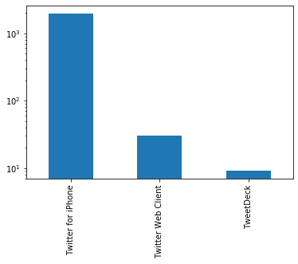

```python
# source of data
df.source.value_counts().plot(kind='bar', logy=True);
```

```python
dfa = df.query('favorite_count <=60000')
```

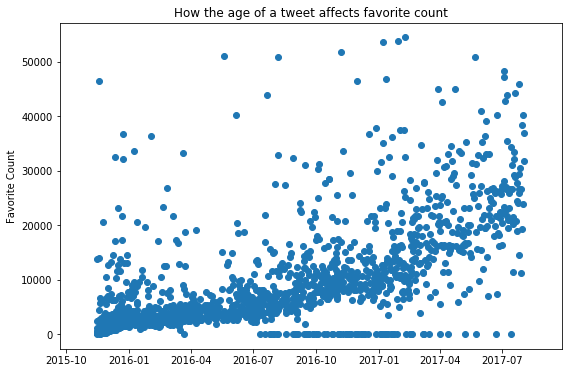

```python
# how favorite count related to the age of tweet
fig,ax = plt.subplots(figsize=(9,6))
ax.set_title('How the age of a tweet affects favorite count')
ax.set_ylabel('Favorite Count')
ax.scatter(x=dfa.timestamp, y=dfa.favorite_count);
```

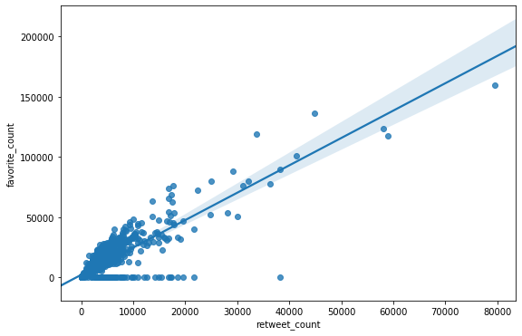

```python
# make sense with a positive linear between retweet and favorite
_, ax = plt.subplots(figsize=(9,6))
sns.regplot(x="retweet_count", y="favorite_count", data=df);
```

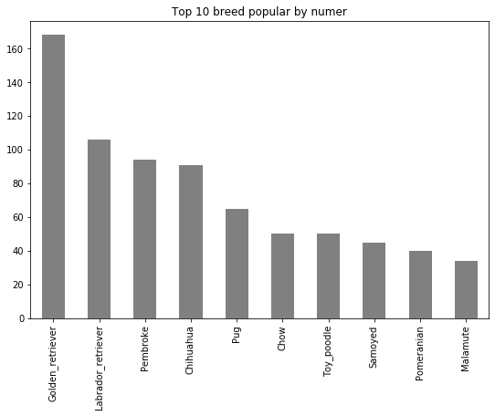

```python
# top 10 popular breed by number
_, ax = plt.subplots(figsize=(9,6))
ax.set_title('Top 10 breed popular by numer')
df.query('breed!="Unknown"').breed.value_counts().nlargest(10).plot(kind='bar', color='grey');
```

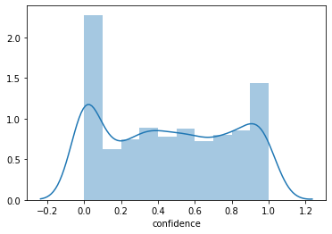

```python
# how confidence the neutral network to predict dog breed
ax = sns.distplot(df['confidence'])
```

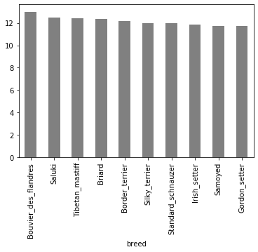

```python
# how about the score on each dog breed
df.query('breed!="Unknown"').groupby('breed')['rating'].mean().sort_values(ascending=False).nlargest(10).plot(kind='bar', color='grey');
```

```python
# how many Bouvier dogs were rated:
df.query('breed=="Bouvier_des_flandres"').count()
```

```
tweet_id          1
timestamp         1
source            1
text              1
rating            1
name              1
stage             1
breed             1
confidence        1
favorite_count    1
retweet_count     1
dtype: int64
```

- only one dog was rated, this skew the rating

```python
# first create a TimeSeries containing breed and numeber of dogs
counts = df.query("breed!='Unknown'")['breed'].value_counts()
```

```python
# I select only the breed with more than 11 individual dogs were rated
df_avg = df[df.breed.isin(counts[counts>11].index)]
```

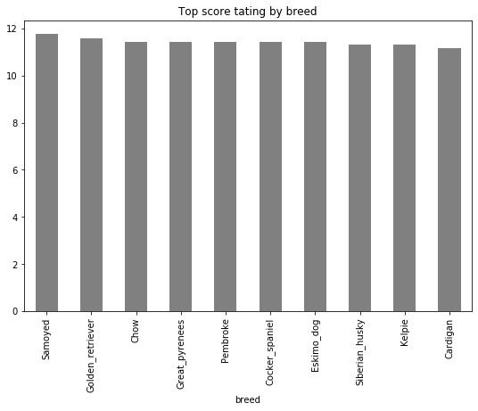

```python
_, ax = plt.subplots(figsize=(9,6))
ax.set_title("Top score tating by breed")
df_avg.groupby('breed').rating.mean().sort_values(ascending=False).nlargest(10).plot(kind='bar', color='grey');
```

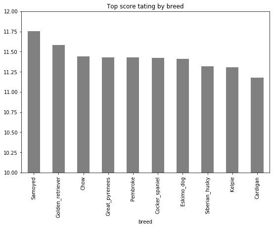

```python
# or zoom in for easier comparison
_, ax = plt.subplots(figsize=(9,6))
ax.set_title("Top score tating by breed")
ax.set_ylim(10,12)
df_avg.groupby('breed').rating.mean().sort_values(ascending=False).nlargest(10).plot(kind='bar', color='grey');
```

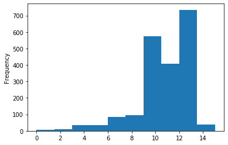

```python
# how score distribution look like
df.rating.plot(kind='hist', bins=10);
```

```python
df.rating.describe()
```

```
count    2017.000000
mean       10.576599
std         2.163507
min         0.000000
25%        10.000000
50%        11.000000
75%        12.000000
max        15.000000
Name: rating, dtype: float64
```

[figure not shown]

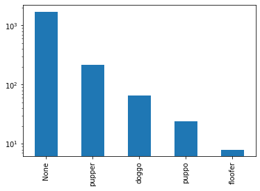

```python
df.stage.value_counts().plot(kind='bar', logy=True);
```

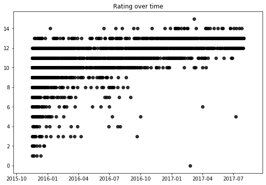

```python
# how the rating change over time
_, ax = plt.subplots(figsize=(9,6))
ax.set_title('Rating over time')
ax.scatter(x=df.timestamp, y=df.rating, c='black', alpha=0.8)
```

```python
top10_favorite_by_breed = df.query('breed!="Unknown"').groupby(['breed']).favorite_count.sum().sort_values(ascending=False).nlargest(10)
top10_breed = df.query('breed!="Unknown"').breed.value_counts().head(10)
```

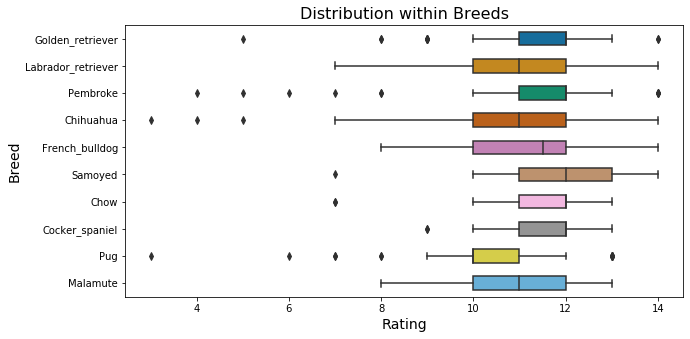

```python
fig, ax = plt.subplots(figsize=(10,5))
bplot = sns.boxplot(y = 'breed', x = 'rating',
                    data = df,
                    orient = 'h',
                    width = 0.5,
                    palette = "colorblind",
                    order = top10_favorite_by_breed.index.tolist())

ax.set_title('Distribution within Breeds', fontsize = 16)
ax.set_ylabel("Breed",  fontsize = 14)
ax.set_xlabel('Rating',  fontsize = 14);
```